# Enrichment Analysis of H3K27ac peaks III

last changed: 2023-08-29

# Feature annotation of H3K27ac peaks

## Data processing

Load the `rlog` transformed DESeq data set and construct the required data frames. The function `assay` returns the values and `colData` returns the information about the experimental design.

```r
> rlog.heat <- readRDS(file = "./../Significance_testing/Data/rlog_H3K27ac_sig.rds")
> head(rlog.heat)
```

```
## class: DESeqTransform
## dim: 6 22
## metadata(1): version
## assays(1): ''
## rownames(6): chr1:777858-779502 chr1:998679-1002226 ...
##   chr1:1202874-1203283 chr1:1204698-1205972
## rowData names(7): baseMean baseVar ... dispFit rlogIntercept
## colnames(22): U2OS31_T0h_Rep1 U2OS31_T0h_Rep2 ... U2OS33_T4h_Rep2
##   U2OS33_T4h_Rep3
## colData names(4): construct replica time sizeFactor
```

```r
> m.H3.ac <- assay(rlog.heat)
> head(m.H3.ac)
```

```
##                      U2OS31_T0h_Rep1 U2OS31_T0h_Rep2 U2OS31_T0h_Rep3
## chr1:777858-779502          6.644882        7.047764        6.843831
## chr1:998679-1002226         7.498502        8.017057        7.874621
## chr1:1062482-1064839        6.936592        7.241185        7.003333
## chr1:1200210-1201807        6.934436        7.513163        7.134582
## chr1:1202874-1203283        3.356625        3.822526        3.791844
## chr1:1204698-1205972        4.254665        4.742891        4.917207
##                      U2OS31_T1h_Rep1 U2OS31_T1h_Rep2 U2OS31_T1h_Rep3
## chr1:777858-779502          6.517474        6.703328        6.873693
## chr1:998679-1002226         7.998243        8.467343        8.302465
## chr1:1062482-1064839        7.626672        7.742398        7.666093
## chr1:1200210-1201807        7.565851        7.760794        7.677449
## chr1:1202874-1203283        3.934671        4.003246        4.427764
## chr1:1204698-1205972        5.122689        5.762440        5.675096
##                      U2OS31_T2h_Rep1 U2OS31_T2h_Rep2 U2OS31_T4h_Rep1
## chr1:777858-779502          6.640883        6.517778        7.088908
## chr1:998679-1002226         8.054719        7.931793        7.407744
## chr1:1062482-1064839        7.485299        7.034059        7.056250
## chr1:1200210-1201807        7.743524        7.840957        7.348425
## chr1:1202874-1203283        4.307967        4.287953        3.557889
## chr1:1204698-1205972        5.234419        5.331420        4.751368
##                      U2OS31_T4h_Rep2 U2OS33_T0h_Rep1 U2OS33_T0h_Rep2
## chr1:777858-779502          6.653240        7.191532        7.220966
## chr1:998679-1002226         6.942857        7.627258        8.156514
## chr1:1062482-1064839        6.902423        6.772283        6.647448
## chr1:1200210-1201807        7.378682        7.085342        7.456336
## chr1:1202874-1203283        3.467119        3.387016        3.619754
## chr1:1204698-1205972        4.530288        4.591392        5.044981
##                      U2OS33_T0h_Rep3 U2OS33_T1h_Rep1 U2OS33_T1h_Rep2
## chr1:777858-779502          6.802851        7.140648        7.189506
## chr1:998679-1002226         7.983411        8.777242        9.068580
## chr1:1062482-1064839        6.585536        7.619277        7.763149
## chr1:1200210-1201807        6.967209        7.775634        8.128662
## chr1:1202874-1203283        3.725291        4.279163        4.098830
## chr1:1204698-1205972        4.590939        5.295389        5.532942
##                      U2OS33_T1h_Rep3 U2OS33_T2h_Rep1 U2OS33_T2h_Rep2
## chr1:777858-779502          6.831799        6.866234        6.606008
## chr1:998679-1002226         8.777677        8.763022        8.849320
## chr1:1062482-1064839        7.778628        7.525321        7.322127
## chr1:1200210-1201807        7.896455        7.767084        7.746612
## chr1:1202874-1203283        4.437457        4.206605        4.138575
## chr1:1204698-1205972        5.649694        5.825150        5.600117
##                      U2OS33_T2h_Rep3 U2OS33_T4h_Rep1 U2OS33_T4h_Rep2
## chr1:777858-779502          6.513053        6.555047        7.007727
## chr1:998679-1002226         8.339706        7.537214        7.723678
## chr1:1062482-1064839        6.921511        7.219436        6.845753
## chr1:1200210-1201807        7.732785        7.415408        7.178515
## chr1:1202874-1203283        4.006166        3.591726        3.267218
## chr1:1204698-1205972        5.604686        5.088697        4.895844
##                      U2OS33_T4h_Rep3
## chr1:777858-779502          6.456581
## chr1:998679-1002226         7.689625
## chr1:1062482-1064839        6.742765
## chr1:1200210-1201807        7.139855
## chr1:1202874-1203283        3.315074
## chr1:1204698-1205972        5.347766
```

```r
> info.H3.ac <- data.frame(colData(rlog.heat))
> paged_table(info.H3.ac)
```

|  | construct | replica | time | sizeFactor |
| --- | --- | --- | --- | --- |
| U2OS31_T0h_Rep1 | U2OS31 | Rep1 | 0 | 0.9713745 |
| U2OS31_T0h_Rep2 | U2OS31 | Rep2 | 0 | 0.9677638 |
| U2OS31_T0h_Rep3 | U2OS31 | Rep3 | 0 | 1.4070125 |
| U2OS31_T1h_Rep1 | U2OS31 | Rep1 | 1 | 1.3427846 |
| U2OS31_T1h_Rep2 | U2OS31 | Rep2 | 1 | 1.3689437 |
| U2OS31_T1h_Rep3 | U2OS31 | Rep3 | 1 | 1.3748857 |
| U2OS31_T2h_Rep1 | U2OS31 | Rep1 | 2 | 0.9648885 |
| U2OS31_T2h_Rep2 | U2OS31 | Rep2 | 2 | 1.3894730 |
| U2OS31_T4h_Rep1 | U2OS31 | Rep1 | 4 | 1.0879097 |
| U2OS31_T4h_Rep2 | U2OS31 | Rep2 | 4 | 1.2114263 |

[output cut: 12 more lines]

Next the `GRanges` object can be constructed using the `rownames` of the DESeq data set, which contain information about the location of each peak.

```r
> chr <- str_split_i(rownames(m.H3.ac), ":", 1)
> pos <- str_split_i(rownames(m.H3.ac), ":", 2)
> start <- as.integer(str_split_i(pos, "-", 1))
> end <- as.integer(str_split_i(rownames(m.H3.ac), "-", 2))
>
> peaks.H3ac <- GRanges(seqnames = chr,
+                         ranges =IRanges(start = start, end = end))
> head(peaks.H3ac)
```

```
## GRanges object with 6 ranges and 0 metadata columns:
##       seqnames          ranges strand
##          <Rle>       <IRanges>  <Rle>
##   [1]     chr1   777858-779502      *
##   [2]     chr1  998679-1002226      *
##   [3]     chr1 1062482-1064839      *
##   [4]     chr1 1200210-1201807      *
##   [5]     chr1 1202874-1203283      *
##   [6]     chr1 1204698-1205972      *
##   -------
##   seqinfo: 34 sequences from an unspecified genome; no seqlengths
```

```r
> saveRDS(peaks.H3ac, "./Data/peaks_H3ac.rds")
```

To visualize the distance to TSS the by cluster, a `list` containing a entry for  
each cluster with the corresponding peaks is required. Thus, the clustering results are loaded and used to filter the `GRanges` object.

```r
> kmeans.k3 <- readRDS("./../Clustering/Data/kmeans.rds")
>
> lapply(kmeans.k3, head)
```

```
## $cluster
##   chr1:777858-779502  chr1:998679-1002226 chr1:1062482-1064839
##                    2                    1                    1
## chr1:1200210-1201807 chr1:1202874-1203283 chr1:1204698-1205972
##                    1                    1                    1
##
## $centers
##   U2OS31_T0h_Rep1 U2OS31_T0h_Rep2 U2OS31_T0h_Rep3 U2OS31_T1h_Rep1
## 1      -0.9107094      -0.7566079      -0.7069159     -0.10780233
## 2       0.6759502       1.0260492       0.6292887      0.24464281
## 3       1.4963678       0.1281274       0.4890254     -0.02324492
##   U2OS31_T1h_Rep2 U2OS31_T1h_Rep3 U2OS31_T2h_Rep1 U2OS31_T2h_Rep2
## 1       0.6502129      0.57607047       0.5174009        1.022184
## 2       0.1274272     -0.01055102      -0.6339156       -1.159889
## 3      -0.6248805     -0.51913494      -0.6324137       -1.058342
##   U2OS31_T4h_Rep1 U2OS31_T4h_Rep2 U2OS33_T0h_Rep1 U2OS33_T0h_Rep2
## 1      -0.1571308      -0.1267021      -1.0838748      -0.9035251
## 2      -0.4080304      -0.4909725       0.8059179       1.0772501
## 3       0.3000225       0.4444727       1.4928046       0.2018640
##   U2OS33_T0h_Rep3 U2OS33_T1h_Rep1 U2OS33_T1h_Rep2 U2OS33_T1h_Rep3
## 1      -0.7184915    -0.051680842       0.3907944       0.4288748
## 2       0.6743626     0.436558924       0.5116969       0.1474220
## 3       0.6599322    -0.008400519      -0.6667306      -0.3415816
##   U2OS33_T2h_Rep1 U2OS33_T2h_Rep2 U2OS33_T2h_Rep3 U2OS33_T4h_Rep1
## 1       0.7437703       0.9385652       0.8152558     -0.08010668
## 2      -0.5926291      -0.9649092      -0.9629240     -0.49604915
## 3      -0.4862840      -1.2731167      -0.8158056      0.45385189
##   U2OS33_T4h_Rep2 U2OS33_T4h_Rep3
## 1      -0.2484016      -0.2311799
## 2      -0.2484116      -0.3882853
## 3       0.3193091       0.4641572
##
## $totss
## [1] 217605.8
##
## $withinss
## [1] 59666.03 23202.91 28801.15
##
## $tot.withinss
## [1] 111670.1
##
## $betweenss
## [1] 105935.7
##
## $size
## [1] 5468 2219 3301
##
## $iter
## [1] 2
##
## $ifault
## [1] 0
```

```r
> clus.kmeans <- melt(kmeans.k3$cluster)
> clus.kmeans <- cbind(clus.kmeans, 1:nrow(clus.kmeans))
> colnames(clus.kmeans) <- c("cluster", "ind")
> clus.kmeans <- clus.kmeans[order(clus.kmeans[, "cluster"]), ]
>
> paged_table(clus.kmeans)
```

|  | cluster | ind |
| --- | --- | --- |
| chr1:998679-1002226 | 1 | 2 |
| chr1:1062482-1064839 | 1 | 3 |
| chr1:1200210-1201807 | 1 | 4 |
| chr1:1202874-1203283 | 1 | 5 |
| chr1:1204698-1205972 | 1 | 6 |
| chr1:1207150-1209839 | 1 | 7 |
| chr1:2087657-2089779 | 1 | 12 |
| chr1:2131447-2134275 | 1 | 13 |
| chr1:2193311-2195820 | 1 | 14 |
| chr1:2447631-2448846 | 1 | 19 |

[output cut: 9990 more lines]

```r
> ind.cluster1 <- clus.kmeans[which(clus.kmeans[, "cluster"] == 1), "ind"]
> ind.cluster2 <- clus.kmeans[which(clus.kmeans[, "cluster"] == 2), "ind"]
> ind.cluster3 <- clus.kmeans[which(clus.kmeans[, "cluster"] == 3), "ind"]
>
> peaks.k1 <- peaks.H3ac[ind.cluster1, ]
> peaks.k2 <- peaks.H3ac[ind.cluster2, ]
> peaks.k3 <- peaks.H3ac[ind.cluster3, ]
>
> peaks <- list(cluster_1 = peaks.k1, cluster_2 = peaks.k2,
+               cluster_3 = peaks.k3)
```

## Average distance to TSS

The `GRanges` list can then be used to plot the average distance to the TSS by cluster.

```r
> hg38 <- TxDb.Hsapiens.UCSC.hg38.knownGene
> promoter <- getPromoters(TxDb = hg38, upstream=3000, downstream=3000)
> tagM.peaks <- lapply(peaks, getTagMatrix, windows=promoter)
```

```
## >> preparing start_site regions by gene... 2023-08-29 12:40:21
## >> preparing tag matrix...  2023-08-29 12:40:21
## >> preparing start_site regions by gene... 2023-08-29 12:41:09
## >> preparing tag matrix...  2023-08-29 12:41:09
## >> preparing start_site regions by gene... 2023-08-29 12:41:51
## >> preparing tag matrix...  2023-08-29 12:41:51
```

```
## >> plotting figure...             2023-08-29 12:42:33
```

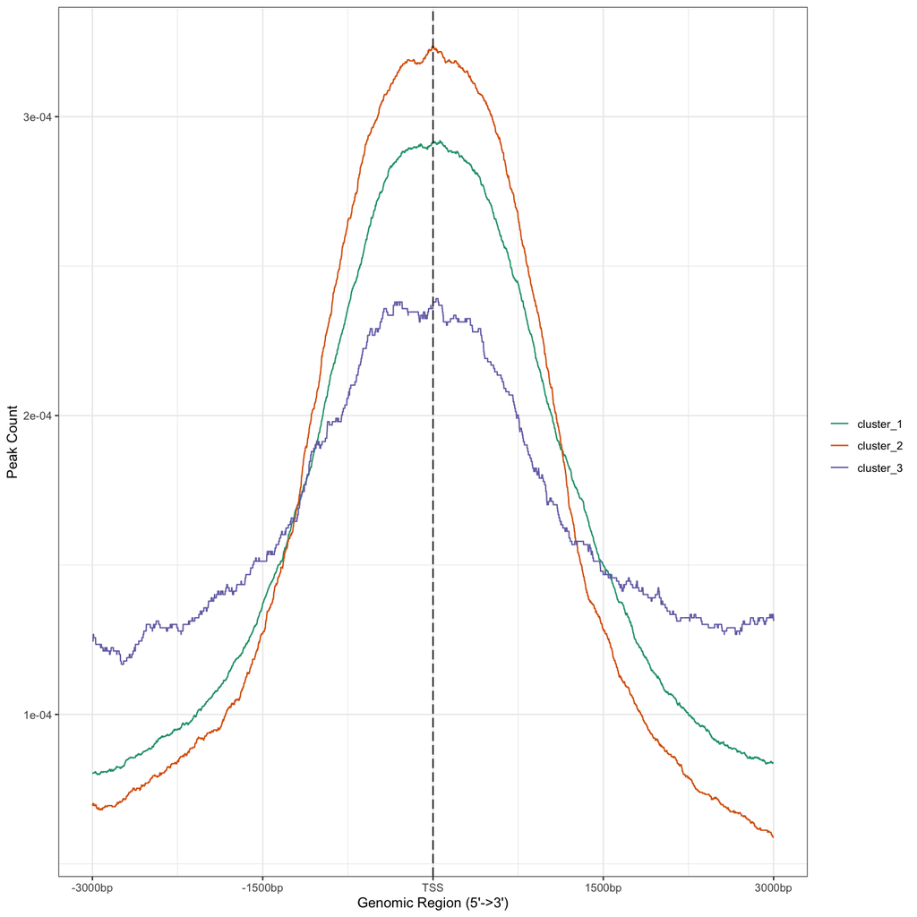

```r
> plotAvgProf(tagM.peaks, TxDb = hg38, xlim=c(-3000, 3000),
+              xlab = "Genomic Region (5'->3')", ylab = "Peak Count") +
+   scale_color_manual(values = brewer.pal(n = 3, name = "Dark2"))
```

## Feature annotation

Next, the peaks were annotated to genes using `annotatePeak` and all known human genes. The resulting object was then plotted with `plotAnnoBar`, to visualize the distribution of features among peaks.

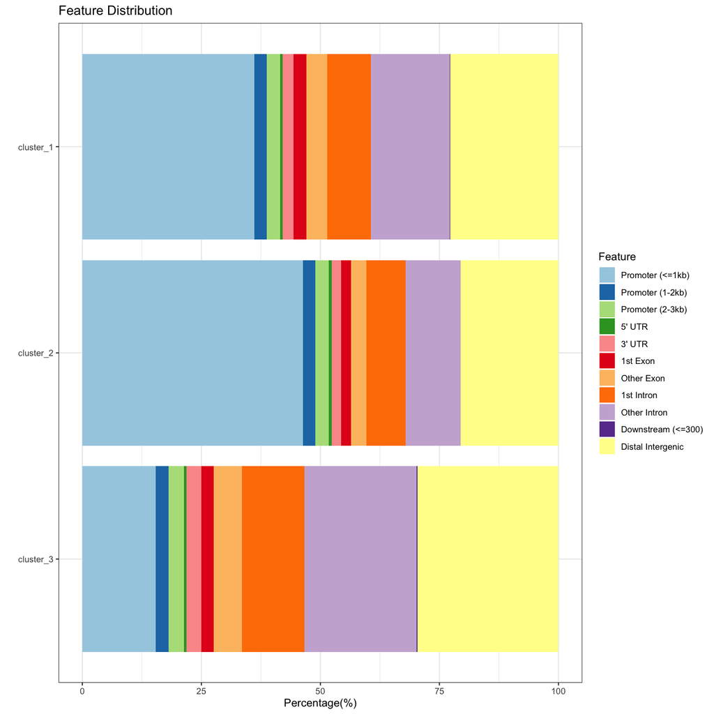

```r
> anno.list <- lapply(peaks, annotatePeak, TxDb = hg38,
+                          tssRegion=c(-3000, 3000), verbose=FALSE)
>
> plotAnnoBar(anno.list)
```

# Enrichment Analysis

## Data processing

For the enrichment analysis the peaks were annotated to only coding genes within a range of -1 to 1 kb from the transcription start site (TSS). For this the peaks are annotated to using only the protein coding genes.

```r
> TxDb.protein.coding <- loadDb( file="./Data/TxDb.protein.coding.sqlite")
> seqlevelsStyle(TxDb.protein.coding) <- "UCSC"
>
> peak.coding <- lapply(peaks, annotatePeak, TxDb = TxDb.protein.coding,
+                       tssRegion = c(-3000, 3000), verbose=FALSE)
```

Next, the following function was used to translate the ENSEMBL identifiers to ENTREZID.

```r
> # generate required structure:
> conv2table<-function(x){
+   eg = bitr(x@anno$geneId, fromType="ENSEMBL", toType="SYMBOL", OrgDb="org.Hs.eg.db")
+   ez = bitr(x@anno$geneId, fromType="ENSEMBL", toType="ENTREZID", OrgDb="org.Hs.eg.db")
+   anno.table<-x@anno
+   #add gene symbols
+   mx<-match(anno.table$geneId, eg$ENSEMBL)
+   anno.table$gene_symbol<-eg[mx,"SYMBOL"]
+   #add gene entrezID
+   mx<-match(anno.table$geneId, ez$ENSEMBL)
+   anno.table$gene_entrez<-ez[mx,"ENTREZID"]
+
+   res.table<-cbind(
+     chr=as.vector(seqnames(anno.table)),
+     start=start(anno.table),
+     end=end(anno.table),
+     name=anno.table$name,
+     peak.p_adj=anno.table$qValue,
+     strand=rep(".", length(anno.table)),
+     genome_anno=anno.table$annotation,
+     gene_symbol=anno.table$gene_symbol,
+     gene_entrez=anno.table$gene_entrez,
+     distanceToTSS=anno.table$distanceToTSS,
+     transcriptId=anno.table$transcriptId,
+     geneId_ensembl=anno.table$geneId)
+ }
>
> peak.coding.ID <- lapply(peak.coding, function(n) conv2table(n))
> lapply(peak.coding.ID, head)
```

```
## $cluster_1
##      chr    start     end       strand genome_anno         gene_symbol
## [1,] "chr1" "998679"  "1002226" "."    "Promoter (<=1kb)"  "ISG15"
## [2,] "chr1" "1062482" "1064839" "."    "Distal Intergenic" "RNF223"
## [3,] "chr1" "1200210" "1201807" "."    "Distal Intergenic" "TNFRSF18"
## [4,] "chr1" "1202874" "1203283" "."    "Promoter (2-3kb)"  "TNFRSF18"
## [5,] "chr1" "1204698" "1205972" "."    "Promoter (<=1kb)"  "TNFRSF18"
## [6,] "chr1" "1207150" "1209839" "."    "Promoter (<=1kb)"  "TNFRSF18"
##      gene_entrez distanceToTSS transcriptId      geneId_ensembl
## [1,] "9636"      "0"           "ENST00000624697" "ENSG00000187608"
## [2,] "401934"    "9467"        "ENST00000453464" "ENSG00000237330"
## [3,] "8784"      "3873"        "ENST00000486728" "ENSG00000186891"
## [4,] "8784"      "2397"        "ENST00000486728" "ENSG00000186891"
## [5,] "8784"      "0"           "ENST00000486728" "ENSG00000186891"
## [6,] "8784"      "-558"        "ENST00000379268" "ENSG00000186891"
```

[output cut: 46 more lines]

The resulting list was then filtered for peaks which are within a range of -1 to 1 kb from the TSS.

```r
> peak.coding.1kb <- lapply(peak.coding.ID, function(x)
+   filter(as.data.frame(x),
+          abs(as.integer(as.data.frame(x)$distanceToTSS)) <= 1000))
>
> lapply(peak.coding.1kb, head)
```

```
## $cluster_1
##    chr   start     end strand      genome_anno gene_symbol gene_entrez
## 1 chr1  998679 1002226      . Promoter (<=1kb)       ISG15        9636
## 2 chr1 1204698 1205972      . Promoter (<=1kb)    TNFRSF18        8784
## 3 chr1 1207150 1209839      . Promoter (<=1kb)    TNFRSF18        8784
## 4 chr1 2131447 2134275      . Promoter (<=1kb)       PRKCZ        5590
## 5 chr1 2193311 2195820      . Promoter (<=1kb)      FAAP20      199990
## 6 chr1 3471129 3472582      . Promoter (<=1kb)    ARHGEF16       27237
##   distanceToTSS    transcriptId  geneId_ensembl
## 1             0 ENST00000624697 ENSG00000187608
## 2             0 ENST00000486728 ENSG00000186891
## 3          -558 ENST00000379268 ENSG00000186891
## 4             0 ENST00000471018 ENSG00000067606
## 5             0 ENST00000400919 ENSG00000162585
## 6             0 ENST00000464620 ENSG00000130762
```

[output cut: 32 more lines]

```r
> saveRDS(peak.coding.1kb, file = "./Data/peaks_H3ac_cod1kb.rds")
>
> names(peak.coding.1kb) <- c("1", "2", "3")
> cod.genes.1kb <- lapply(peak.coding.1kb, function(i) as.data.frame(i)$gene_entrez)
```

## Reactome pathway analysis enrichment analysis

Finally, the filtered list with the coding genes can be used for an enrichment analysis using the function `enrichPathway`, which can be plotted using `dotplot`.

```r
> comp.Reac <- compareCluster(geneCluster = cod.genes.1kb,
+                             fun = "enrichPathway",
+                             pvalueCutoff = 0.05,
+                             pAdjustMethod = "BH")
>
> comp.Reac %>% as.data.frame() %>% paged_table()
```

| Cluster | ID | Description | GeneRatio | BgRatio | pvalue | p.adjust | qvalue | geneID | Count |
| --- | --- | --- | --- | --- | --- | --- | --- | --- | --- |
| 1 | R-HSA-1474244 | Extracellular matrix organization | 55/932 | 300/10955 | 3.300946e-08 | 4.452976e-05 | 4.127920e-05 | 5351/4237/23127/7042/7093/960/4038/871/4684/10536/3679/652/4…… | 55 |
| 1 | R-HSA-1474290 | Collagen formation | 25/932 | 90/10955 | 6.890717e-08 | 4.647789e-05 | 4.308512e-05 | 5351/23127/7093/871/10536/4016/1277/3909/50509/4318/1299/1291/1292/10491/1294/26577/5352/8974/667/1310/5118/1508/649/85301/1289 | 25 |
| 1 | R-HSA-1650814 | Collagen biosynthesis and modifying enzymes | 20/932 | 67/10955 | 3.923694e-07 | 1.764354e-04 | 1.635561e-04 | 5351/23127/7093/871/10536/1277/50509/1299/1291/1292/10491/1294/26577/5352/8974/1310/5118/649/85301/1289 | 20 |
| 1 | R-HSA-375165 | NCAM signaling for neurite out-growth | 17/932 | 63/10955 | 1.312427e-05 | 3.721752e-03 | 3.450073e-03 | 783/4684/775/6710/51332/8912/8913/50509/57731/6711/785/6714/1299/1291/1292/776/1289 | 17 |
| 1 | R-HSA-3000178 | ECM proteoglycans | 19/932 | 76/10955 | 1.379448e-05 | 3.721752e-03 | 3.450073e-03 | 7042/4038/4684/3679/7043/176/3687/1277/284217/3909/50509/1299/1291/1292/3913/1404/3912/3371/1289 | 19 |
| 1 | R-HSA-2219530 | Constitutive Signaling by Aberrant PI3K in Cancer | 19/932 | 78/10955 | 2.056098e-05 | 4.622794e-03 | 4.285341e-03 | 4254/2254/145957/2064/3667/6714/5880/5155/5291/5156/374/2250/2549/1839/2246/5159/2264/1956/3084 | 19 |
| 1 | R-HSA-2022090 | Assembly of collagen fibrils and other multimeric structures | 16/932 | 61/10955 | 3.447314e-05 | 6.643466e-03 | 6.158510e-03 | 7093/4016/1277/3909/50509/4318/1299/1291/1292/1294/667/5118/1508/649/85301/1289 | 16 |
| 1 | R-HSA-186797 | Signaling by PDGF | 15/932 | 58/10955 | 7.196413e-05 | 1.213495e-02 | 1.124913e-02 | 9564/50509/6772/6714/1299/1291/1292/5155/5291/5156/6696/5921/5159/5327/1289 | 15 |
| 1 | R-HSA-8875878 | MET promotes cell motility | 12/932 | 41/10955 | 1.038670e-04 | 1.556850e-02 | 1.443204e-02 | 84951/1277/284217/3909/50509/6714/3913/2549/64759/3912/85301/1289 | 12 |
| 1 | R-HSA-419037 | NCAM1 interactions | 12/932 | 42/10955 | 1.342928e-04 | 1.666017e-02 | 1.544402e-02 | 783/4684/775/8912/8913/50509/785/1299/1291/1292/776/1289 | 12 |

[output cut: 27 more lines]

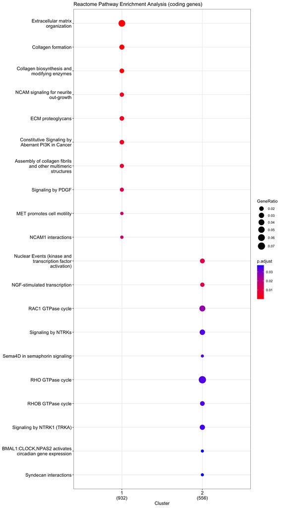

```r
> dotplot(comp.Reac, showCategory = 10,
+         title = "Reactome Pathway Enrichment Analysis (coding genes)")
```

## Gene Ontology enrichment analysis

Exactly the same as above can be done with the function `enrichGO`.

```r
> comp.GO <- compareCluster(geneCluster = cod.genes.1kb,
+                           fun = "enrichGO",
+                           OrgDb = org.Hs.eg.db,
+                           ont = "BP",
+                           readable = T,
+                           pvalueCutoff = 0.05,
+                           pAdjustMethod = "BH")
>
> comp.GO %>% as.data.frame() %>% paged_table()
```

| Cluster | ID | Description | GeneRatio | BgRatio | pvalue | p.adjust | qvalue | geneID | Count |
| --- | --- | --- | --- | --- | --- | --- | --- | --- | --- |
| 1 | GO:0048568 | embryonic organ development | 80/1447 | 453/18614 | 2.665157e-12 | 1.523404e-08 | 1.254587e-08 | MFAP2/EPHB2/TAL1/TBX15/EFNA1/PBX1/TGFB2/WNT3A/PAX2/HMX2/IGF2…… | 80 |
| 1 | GO:0061448 | connective tissue development | 54/1447 | 275/18614 | 1.851357e-10 | 5.291177e-07 | 4.357509e-07 | IL6R/ARID5B/CD44/MDK/SPI1/SLC39A13/ESRRA/SERPINH1/DGAT2/SOX5…… | 54 |
| 1 | GO:0050808 | synapse organization | 76/1447 | 466/18614 | 4.615063e-10 | 8.793234e-07 | 7.241601e-07 | EPHB2/DLGAP3/PTPRF/NFIA/NTNG1/EFNA1/PPFIA4/WNT3A/CACNB2/NRP1…… | 76 |
| 1 | GO:0048562 | embryonic organ morphogenesis | 55/1447 | 294/18614 | 8.278120e-10 | 1.154708e-06 | 9.509506e-07 | MFAP2/EPHB2/TBX15/EFNA1/WNT3A/PAX2/HMX2/MICAL2/YAP1/WNT1/RAR…… | 55 |
| 1 | GO:0072001 | renal system development | 58/1447 | 320/18614 | 1.010066e-09 | 1.154708e-06 | 9.509506e-07 | TP73/NFIA/IL6R/PBX1/TGFB2/NRP1/BICC1/ARID5B/PAX2/EMX2/CAT/LR…… | 58 |
| 1 | GO:0001649 | osteoblast differentiation | 47/1447 | 250/18614 | 1.183484e-08 | 8.220332e-06 | 6.769792e-06 | ALPL/IL6R/WNT3A/IGF2/CAT/CREB3L1/ESRRA/YAP1/PTHLH/GLI1/FGF9/…… | 47 |
| 1 | GO:0051216 | cartilage development | 41/1447 | 203/18614 | 1.218325e-08 | 8.220332e-06 | 6.769792e-06 | CD44/MDK/ESRRA/SERPINH1/SOX5/PTHLH/RARG/HMGA2/CHST11/FGF9/BM…… | 41 |
| 1 | GO:0001654 | eye development | 63/1447 | 385/18614 | 1.260555e-08 | 8.220332e-06 | 6.769792e-06 | MFAP2/EPHB2/BCAR3/LENEP/PBX1/ATP2B4/TGFB2/VIM/NRP1/ATOH7/PAX…… | 63 |
| 1 | GO:0001822 | kidney development | 54/1447 | 310/18614 | 1.589237e-08 | 8.220332e-06 | 6.769792e-06 | TP73/IL6R/PBX1/TGFB2/NRP1/BICC1/ARID5B/PAX2/CAT/LRP4/YAP1/KI…… | 54 |
| 1 | GO:0050804 | modulation of chemical synaptic transmission | 74/1447 | 487/18614 | 1.804181e-08 | 8.220332e-06 | 6.769792e-06 | PRKCZ/EPHB2/DLGAP3/NTNG1/RGS4/ADORA1/WNT3A/GRID1/MYOF/NEURL1…… | 74 |

[output cut: 647 more lines]

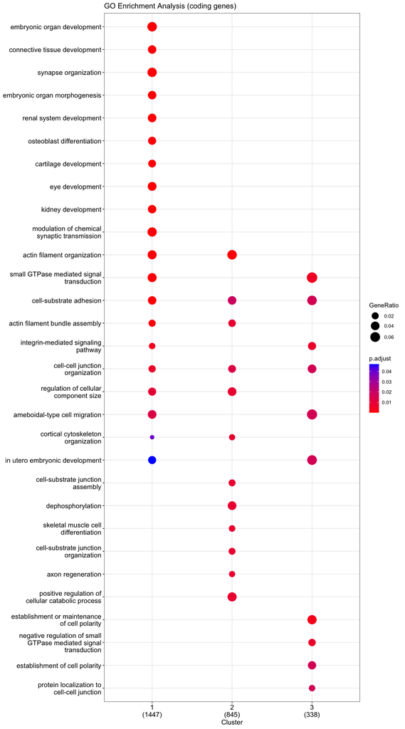

```r
> dotplot(comp.GO, showCategory = 10,
+         title = "GO Enrichment Analysis (coding genes)")
```

## References - packages

- Ahlmann-Eltze C, Hickey P, Pagès H (2023). *MatrixGenerics: S4 Generic Summary Statistic Functions that Operate on Matrix-Like Objects*. doi:10.18129/B9.bioc.MatrixGenerics https://doi.org/10.18129/B9.bioc.MatrixGenerics, R package version 1.12.2, https://bioconductor.org/packages/MatrixGenerics.
- Allaire J, Xie Y, Dervieux C, McPherson J, Luraschi J, Ushey K, Atkins A, Wickham H, Cheng J, Chang W, Iannone R (2023). *rmarkdown: Dynamic Documents for R*. R package version 2.23, https://github.com/rstudio/rmarkdown. Xie Y, Allaire J, Grolemund G (2018). *R Markdown: The Definitive Guide*. Chapman and Hall/CRC, Boca Raton, Florida. ISBN 9781138359338, https://bookdown.org/yihui/rmarkdown. Xie Y, Dervieux C, Riederer E (2020). *R Markdown Cookbook*. Chapman and Hall/CRC, Boca Raton, Florida. ISBN 9780367563837, https://bookdown.org/yihui/rmarkdown-cookbook.
- Arora S, Morgan M, Carlson M, Pagès H (2023). *GenomeInfoDb: Utilities for manipulating chromosome names, including modifying them to follow a particular naming style*. doi:10.18129/B9.bioc.GenomeInfoDb https://doi.org/10.18129/B9.bioc.GenomeInfoDb, R package version 1.36.0, https://bioconductor.org/packages/GenomeInfoDb.
- Bengtsson H (2023). *matrixStats: Functions that Apply to Rows and Columns of Matrices (and to Vectors)*. R package version 1.0.0, https://CRAN.R-project.org/package=matrixStats.
- Carlson M (2023). *org.Hs.eg.db: Genome wide annotation for Human*. R package version 3.17.0.
- Huber W, Carey VJ, Gentleman R, Anders S, Carlson M, Carvalho BS, Bravo HC, Davis S, Gatto L, Girke T, Gottardo R, Hahne F, Hansen KD, Irizarry RA, Lawrence M, Love MI, MacDonald J, Obenchain V, Ole’s AK, Pag`es H, Reyes A, Shannon P, Smyth GK, Tenenbaum D, Waldron L, Morgan M (2015). “Orchestrating high-throughput genomic analysis with Bioconductor.” *Nature Methods*, *12*(2), 115-121. http://www.nature.com/nmeth/journal/v12/n2/full/nmeth.3252.html.
- Huber, W., Carey, J. V, Gentleman, R., Anders, S., Carlson, M., Carvalho, S. B, Bravo, C. H, Davis, S., Gatto, L., Girke, T., Gottardo, R., Hahne, F., Hansen, D. K, Irizarry, A. R, Lawrence, M., Love, I. M, MacDonald, J., Obenchain, V., Ole’s, K. A, Pag`es, H., Reyes, A., Shannon, P., Smyth, K. G, Tenenbaum, D., Waldron, L., Morgan, M. (2015). “Orchestrating high-throughput genomic analysis with Bioconductor.” *Nature Methods*, *12*(2), 115-121. http://www.nature.com/nmeth/journal/v12/n2/full/nmeth.3252.html.
- Lawrence M, Huber W, Pagès H, Aboyoun P, Carlson M, Gentleman R, Morgan M, Carey V (2013). “Software for Computing and Annotating Genomic Ranges.” *PLoS Computational Biology*, *9*. doi:10.1371/journal.pcbi.1003118 https://doi.org/10.1371/journal.pcbi.1003118, http://www.ploscompbiol.org/article/info%3Adoi%2F10.1371%2Fjournal.pcbi.1003118.
- Lawrence M, Huber W, Pagès H, Aboyoun P, Carlson M, Gentleman R, Morgan M, Carey V (2013). “Software for Computing and Annotating Genomic Ranges.” *PLoS Computational Biology*, *9*. doi:10.1371/journal.pcbi.1003118 https://doi.org/10.1371/journal.pcbi.1003118, http://www.ploscompbiol.org/article/info%3Adoi%2F10.1371%2Fjournal.pcbi.1003118.
- Lawrence M, Huber W, Pagès H, Aboyoun P, Carlson M, Gentleman R, Morgan M, Carey V (2013). “Software for Computing and Annotating Genomic Ranges.” *PLoS Computational Biology*, *9*. doi:10.1371/journal.pcbi.1003118 https://doi.org/10.1371/journal.pcbi.1003118, http://www.ploscompbiol.org/article/info%3Adoi%2F10.1371%2Fjournal.pcbi.1003118.
- Love MI, Huber W, Anders S (2014). “Moderated estimation of fold change and dispersion for RNA-seq data with DESeq2.” *Genome Biology*, *15*, 550. doi:10.1186/s13059-014-0550-8 https://doi.org/10.1186/s13059-014-0550-8.
- Makowski D, Lüdecke D, Patil I, Thériault R, Ben-Shachar M, Wiernik B (2023). “Automated Results Reporting as a Practical Tool to Improve Reproducibility and Methodological Best Practices Adoption.” *CRAN*. https://easystats.github.io/report/.
- Morgan M, Obenchain V, Hester J, Pagès H (2023). *SummarizedExperiment: SummarizedExperiment container*. doi:10.18129/B9.bioc.SummarizedExperiment https://doi.org/10.18129/B9.bioc.SummarizedExperiment, R package version 1.30.2, https://bioconductor.org/packages/SummarizedExperiment.
- Neuwirth E (2022). *RColorBrewer: ColorBrewer Palettes*. R package version 1.1-3, https://CRAN.R-project.org/package=RColorBrewer.
- Pagès H, Carlson M, Falcon S, Li N (2023). *AnnotationDbi: Manipulation of SQLite-based annotations in Bioconductor*. doi:10.18129/B9.bioc.AnnotationDbi https://doi.org/10.18129/B9.bioc.AnnotationDbi, R package version 1.62.1, https://bioconductor.org/packages/AnnotationDbi.
- Pagès H, Lawrence M, Aboyoun P (2023). *S4Vectors: Foundation of vector-like and list-like containers in Bioconductor*. doi:10.18129/B9.bioc.S4Vectors https://doi.org/10.18129/B9.bioc.S4Vectors, R package version 0.38.1, https://bioconductor.org/packages/S4Vectors.
- R Core Team (2023). *R: A Language and Environment for Statistical Computing*. R Foundation for Statistical Computing, Vienna, Austria. https://www.R-project.org/.
- Team BC, Maintainer BP (2023). *TxDb.Hsapiens.UCSC.hg38.knownGene: Annotation package for TxDb object(s)*. R package version 3.17.0.
- Wang Q, Li M, Wu T, Zhan L, Li L, Chen M, Xie W, Xie Z, Hu E, Xu S, Yu G (2022). “Exploring epigenomic datasets by ChIPseeker.” *Current Protocols*, *2*(10), e585. doi:10.1002/cpz1.585 https://doi.org/10.1002/cpz1.585, https://onlinelibrary.wiley.com/share/author/GYJGUBYCTRMYJFN2JFZZ?target=10.1002/cpz1.585. Yu G, Wang L, He Q (2015). “ChIPseeker: an R/Bioconductor package for ChIP peak annotation, comparison and visualization.” *Bioinformatics*, *31*(14), 2382-2383. doi:10.1093/bioinformatics/btv145 https://doi.org/10.1093/bioinformatics/btv145.
- Wickham H (2007). “Reshaping Data with the reshape Package.” *Journal of Statistical Software*, *21*(12), 1-20. http://www.jstatsoft.org/v21/i12/.
- Wickham H (2016). *ggplot2: Elegant Graphics for Data Analysis*. Springer-Verlag New York. ISBN 978-3-319-24277-4, https://ggplot2.tidyverse.org.
- Wickham H (2022). *stringr: Simple, Consistent Wrappers for Common String Operations*. R package version 1.5.0, https://CRAN.R-project.org/package=stringr.
- Wickham H, François R, Henry L, Müller K, Vaughan D (2023). *dplyr: A Grammar of Data Manipulation*. R package version 1.1.2, https://CRAN.R-project.org/package=dplyr.
- Wu T, Hu E, Xu S, Chen M, Guo P, Dai Z, Feng T, Zhou L, Tang W, Zhan L, Fu x, Liu S, Bo X, Yu G (2021). “clusterProfiler 4.0: A universal enrichment tool for interpreting omics data.” *The Innovation*, *2*(3), 100141. doi:10.1016/j.xinn.2021.100141 https://doi.org/10.1016/j.xinn.2021.100141. Yu G, Wang L, Han Y, He Q (2012). “clusterProfiler: an R package for comparing biological themes among gene clusters.” *OMICS: A Journal of Integrative Biology*, *16*(5), 284-287. doi:10.1089/omi.2011.0118 https://doi.org/10.1089/omi.2011.0118.
- Xie Y (2023). *knitr: A General-Purpose Package for Dynamic Report Generation in R*. R package version 1.43, https://yihui.org/knitr/. Xie Y (2015). *Dynamic Documents with R and knitr*, 2nd edition. Chapman and Hall/CRC, Boca Raton, Florida. ISBN 978-1498716963, https://yihui.org/knitr/. Xie Y (2014). “knitr: A Comprehensive Tool for Reproducible Research in R.” In Stodden V, Leisch F, Peng RD (eds.), *Implementing Reproducible Computational Research*. Chapman and Hall/CRC. ISBN 978-1466561595.
- Yu G, He Q (2016). “ReactomePA: an R/Bioconductor package for reactome pathway analysis and visualization.” *Molecular BioSystems*, *12*(12), 477-479. doi:10.1039/C5MB00663E https://doi.org/10.1039/C5MB00663E, http://pubs.rsc.org/en/Content/ArticleLanding/2015/MB/C5MB00663E.